# PA1_template.Rmd

# Step Activity Analysis

#### For this assignment we are going to be looking at step data taken over time per five minute intervals.

#### Cleaning the data

For this section we are going to be looking at the data on a daily basis, therefore we will need to group the data by date and drop any NA values in the dataset. We do that using the dplyr and data.table packages. It is now time to load in the dataset and then filter it, group it, summarise it and select it to fit our needs.

```r
activity = data.table(read.csv('activity.csv'))

grouped_day = activity %>%
    filter(!is.na(steps)) %>%
    group_by(date) %>%
    summarise_each(funs(sum)) %>%
    select(date,steps)

grouped_interval = activity %>%
    filter(!is.na(steps)) %>%
    group_by(interval) %>%
    summarise_each(funs(mean)) %>%
    select(interval,steps)
```

#### Now that we have the data loaded in and transformed into the shape that we need, its time to plot it out as requested. We will be doing the following things:

1.Make a histogram of the total number of steps taken each day.  
2.Calculate and report the mean and median total number of steps taken per day.

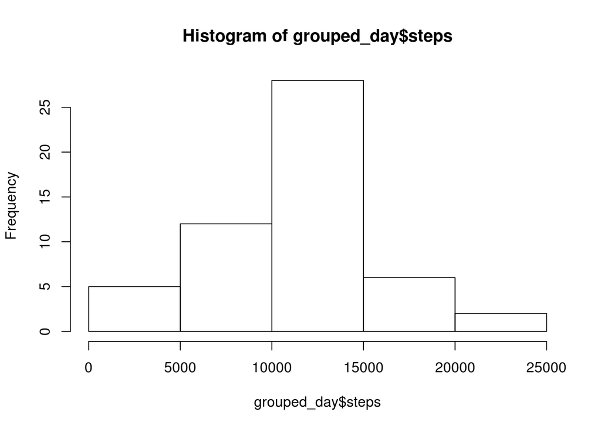

```r
hist(grouped_day$steps)
```

```r
Mean = paste('Mean: ',mean(grouped_day$steps))
Median = paste('Median: ',median(grouped_day$steps))
print(c(Mean,Median))
```

```
## [1] "Mean:  10766.1886792453" "Median:  10765"
```

### For the second step in the analysis, we will be doing the following things:

1. Make a time series plot (i.e. type = “l”) of the 5-minute interval (x-axis) and the average number of steps taken, averaged across all days (y-axis).
2. Which 5-minute interval, on average across all the days in the dataset, contains the maximum number of steps?

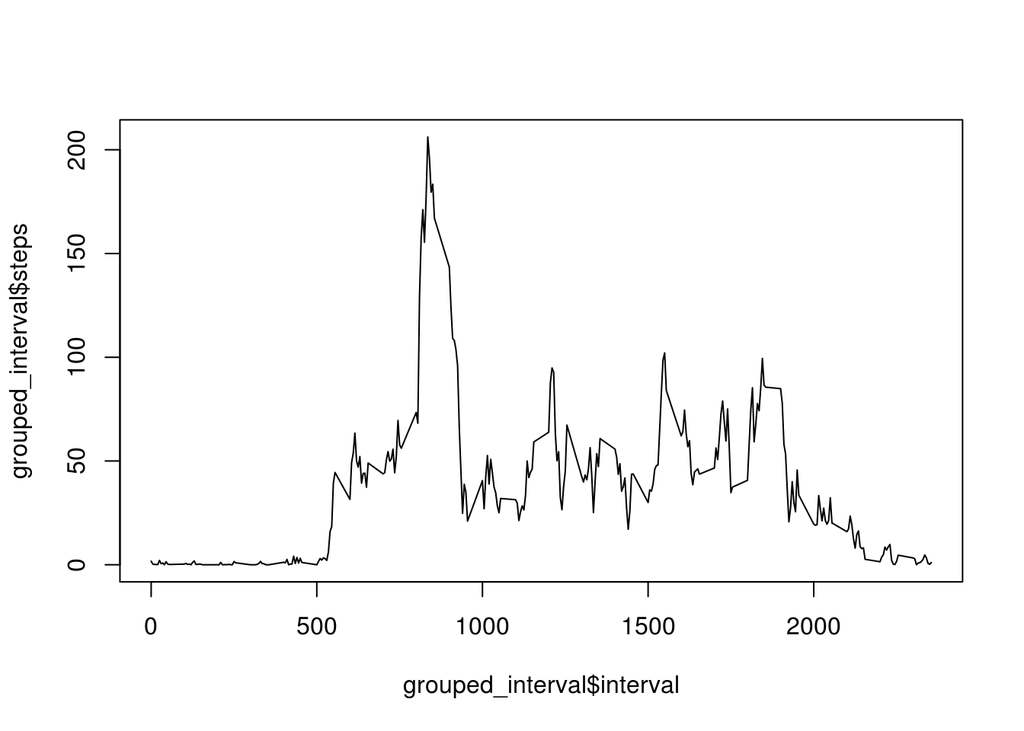

```r
plot(grouped_interval$interval,grouped_interval$steps,
     type = 'l')
```

```r
head(arrange(grouped_interval,desc(steps)),1)
```

```
##   interval    steps
## 1      835 206.1698
```

### Now that we’ve finished that, we are going to impute values for the NA steps and see if that affects our previous findings at all.

```r
print(sum(is.na(activity$steps)))
```

```
## [1] 2304
```

```r
## Create a function that imputes data with the mean of the interval's steps
IntervalImpute = function(data_set){
    unique_intervals = unique(data_set$interval)
    filtered_interval = {}
    complete_data_set = data_set

    for(interv in unique_intervals){
        only_steps = data_set %>% filter(interval == interv & !is.na(steps)) %>% select(steps)
        steps_mean = mean(only_steps$steps)
        complete_data_set = complete_data_set %>%
            mutate(steps = ifelse(is.na(steps) & interval == interv & is.na(steps), steps_mean,steps))
    }

    return(complete_data_set)
}
complete_activity = IntervalImpute(activity)
head(activity)
```

```
##    steps       date interval
## 1:    NA 2012-10-01        0
## 2:    NA 2012-10-01        5
## 3:    NA 2012-10-01       10
## 4:    NA 2012-10-01       15
## 5:    NA 2012-10-01       20
## 6:    NA 2012-10-01       25
```

```r
head(complete_activity)
```

```
##        steps       date interval
## 1: 1.7169811 2012-10-01        0
## 2: 0.3396226 2012-10-01        5
## 3: 0.1320755 2012-10-01       10
## 4: 0.1509434 2012-10-01       15
## 5: 0.0754717 2012-10-01       20
## 6: 2.0943396 2012-10-01       25
```

#### For the sake of comparison I’ve included a head() command for the dataset with missing values (activity) as well as the complete dataset (complete_activity).

#### *The big question though is whether or not imputing these values has any substantial effect on the insights we achieve from our data. Let’s take a look at a histogram that is set up identically to the one from problem 1.*

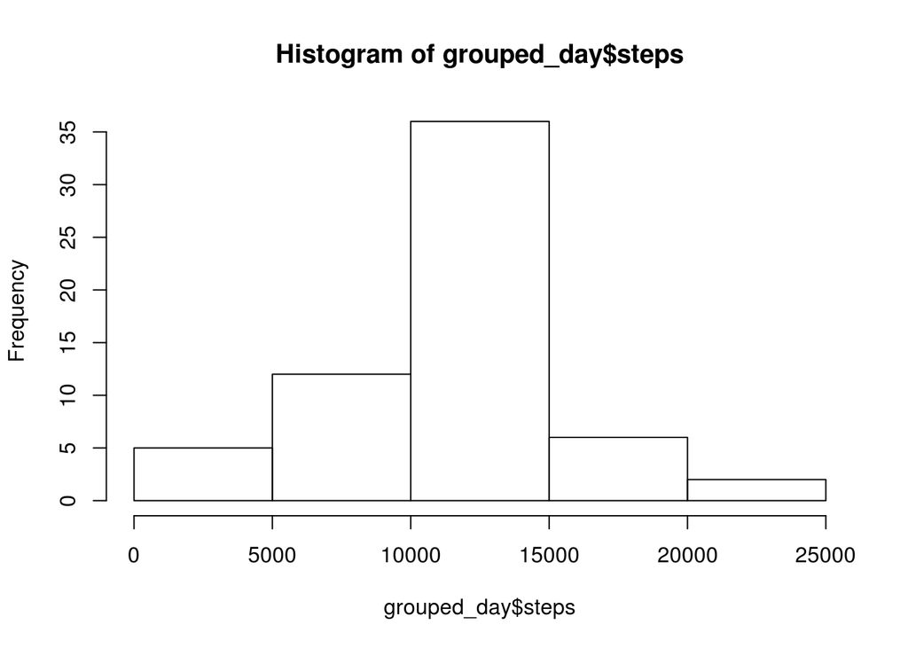

```r
grouped_day = complete_activity %>%
    filter(!is.na(steps)) %>%
    group_by(date) %>%
    summarise_each(funs(sum)) %>%
    select(date,steps)

hist(grouped_day$steps)
```

```r
Mean = paste('Mean: ',mean(grouped_day$steps))
Median = paste('Median: ',median(grouped_day$steps))
print(c(Mean,Median))
```

```
## [1] "Mean:  10766.1886792453"   "Median:  10766.1886792453"
```

#### Are you as surprised by the results as I am? From at least a visual standpoint, the histograms show exactly the same trend.

#### *Finally, let’s take a look at the steps taken during the weekdays versus the weekends. Do you think we’ll see any significant trends?*

#### We will be making judicious use of the ‘lubridate’ package for this section.

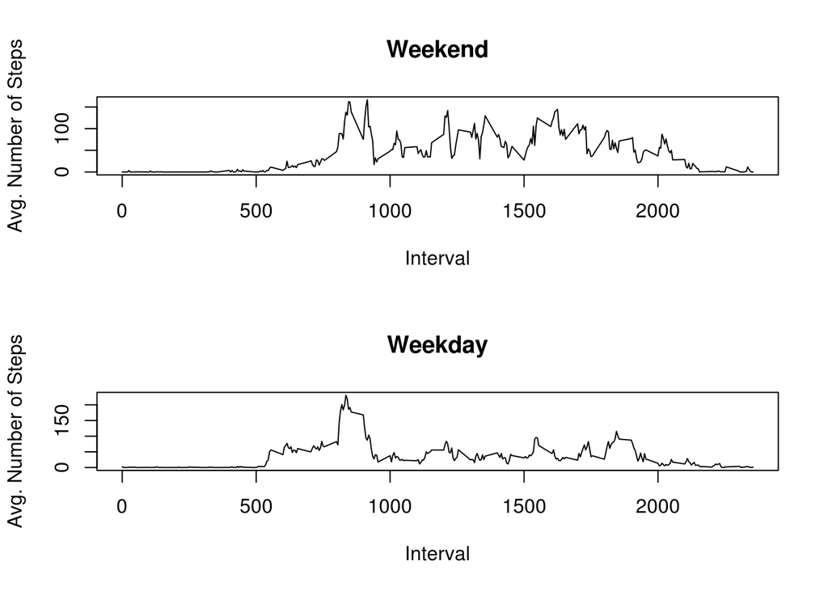

```r
## Convert the complete_activity date column to dates
complete_activity$date = ymd(complete_activity$date)

## Mutate a new column to show whether it is a weekday or not
complete_activity = complete_activity %>%
    mutate(weekday = ifelse(wday(date) > 1 & wday(date) < 7,TRUE,FALSE)) %>%
    mutate(DayOfWeek = wday(date,label=TRUE))

## Group the complete data by 5-minute interval and weekday or weekend
complete_weekday = complete_activity %>%
    filter(weekday == TRUE) %>%
    group_by(interval) %>%
    summarise_each(funs(mean)) %>%
    select(interval,steps)

complete_weekend = complete_activity %>%
    filter(weekday == FALSE) %>%
    group_by(interval) %>%
    summarise_each(funs(mean)) %>%
    select(interval,steps)

## Create the Plot
par(mfrow=c(2,1))

plot(complete_weekend$interval,complete_weekend$steps,
     type = 'l',
     ylab = 'Avg. Number of Steps',
     xlab = 'Interval',
     main='Weekend')

plot(complete_weekday$interval,complete_weekday$steps,
     type = 'l',
     ylab = 'Avg. Number of Steps',
     xlab = 'Interval',
     main='Weekday')
```

#### As you can see, there is substantially more activity midday on the weekends than there is during the week. Quite an interesting find!